# AF Impact Report subject line testing

# Libraries

```r
library(tidyverse)
library(readxl)
library(splines)
```

# Import data

```r
filepath <- '2018-12-07 Impact Report open click data.xlsx'
recipients <- read_xlsx(
  path = filepath
  , sheet = 'With'
) %>% mutate_if(
  # Replace 0
  is.numeric, replace_na, replace = 0
) %>% mutate(
  # Column data types
  FIRST_KSM_YEAR = as.numeric(FIRST_KSM_YEAR)
  , PROGRAM_GROUP = factor(PROGRAM_GROUP) %>% relevel(ref = 'FT')
  , KLC_CURRENT = !is.na(KLC_CURRENT)
  , KLC_LYBUNT = !is.na(KLC_LYBUNT)
  , AF_STATUS_FY_START = factor(AF_STATUS_FY_START) %>% relevel(ref = 'Lapsed/Non')
  , n = 1
) %>% mutate(
  # Derived variables
  # Any opens or clicks
  DID_OPEN = ifelse(OPENS > 0, TRUE, FALSE)
  , DID_CLICK = ifelse(IMPACT_REPORT_CLICKS > 0, TRUE, FALSE)
  # Decade
  , DECADE = {FIRST_KSM_YEAR/10} %>% floor()
    , DECADE = DECADE * 10
  # AF segment
  , AF_SEG = case_when(
    str_detect(AF_GIVING_SEGMENT, 'Loyal 3+') ~ 'Loyal3+'
    , str_detect(AF_GIVING_SEGMENT, 'Loyal') ~ 'Loyal2'
    , TRUE ~ AF_STATUS
  ) %>% factor()
    %>% relevel(ref = 'Lapsed/Non')
  # Subject line factors
  , HAS_KSM = if_else(str_detect(str_to_lower(EMAIL_SUBJECT), 'kellogg'), TRUE, FALSE)
  , HAS_YOUR = ifelse(str_detect(str_to_lower(EMAIL_SUBJECT), 'your'), TRUE, FALSE)
  , IS_SHORT = ifelse(str_count(EMAIL_SUBJECT, ' ') < 3, TRUE, FALSE)
)
```

# Exploration

Check that I categorized the subject lines correctly.

```r
# Check the email factors were correctly assigned
recipients %>% group_by(EMAIL_SUBJECT) %>%
  summarise(`Has KSM` = max(HAS_KSM), `Has your` = max(HAS_YOUR), `Is short` = max(IS_SHORT))
```

| EMAIL_SUBJECT | Has KSM | Has your | Is short |
| --- | --- | --- | --- |
| 2017-18 Annual Fund Impact Report | 0 | 0 | 0 |
| 2017-18 Impact Report | 0 | 0 | 1 |
| Kellogg Annual Fund Impact Report | 1 | 0 | 0 |
| Kellogg Impact Report | 1 | 0 | 1 |
| Learn about your gift's impact | 0 | 1 | 0 |
| Learn about your Kellogg impact | 1 | 1 | 0 |
| Your gift's impact | 0 | 1 | 1 |
| Your Kellogg impact | 1 | 1 | 1 |

Good.

Check that there are no systematic differences between which groups received each subject line. (This was already done via block randomization but is verified below.)

```r
# Subject line by program
recipients %>% xtabs(n ~ EMAIL_SUBJECT + PROGRAM_GROUP, data = .)
```

```
                                   PROGRAM_GROUP
EMAIL_SUBJECT                        FT EMP EXECED PHD TMP
  2017-18 Annual Fund Impact Report 531  64      1   4 113
  2017-18 Impact Report             543  71      0   3 111
  Kellogg Annual Fund Impact Report 540  71      0   2 110
  Kellogg Impact Report             543  68      0   2 116
  Learn about your gift's impact    535  72      1   5 104
  Learn about your Kellogg impact   540  68      2   3 116
  Your gift's impact                545  67      0   4 121
  Your Kellogg impact               556  61      0   1 125
```

Good.

```r
# Subject line by decade
recipients %>% xtabs(n ~ EMAIL_SUBJECT + DECADE, data = .)
```

```
                                   DECADE
EMAIL_SUBJECT                       1940 1950 1960 1970 1980 1990 2000 2010
  2017-18 Annual Fund Impact Report    1   15   27   49  116  164  178  163
  2017-18 Impact Report                4   13   27   51  117  163  184  169
  Kellogg Annual Fund Impact Report    3   10   29   56  114  167  173  171
  Kellogg Impact Report                1    9   35   53  121  164  172  174
  Learn about your gift's impact       4   12   29   55  108  164  179  166
  Learn about your Kellogg impact      0   16   25   52  119  173  179  165
  Your gift's impact                   3    9   31   56  121  169  180  168
  Your Kellogg impact                  1   10   34   56  125  167  179  171
```

Still good.

```r
# Subject line by AF segment
recipients %>% xtabs(n ~ EMAIL_SUBJECT + AF_SEG, data = .)
```

```
                                   AF_SEG
EMAIL_SUBJECT                       Lapsed/Non Donor Loyal2 Loyal3+ LYBUNT PYBUNT
  2017-18 Annual Fund Impact Report          1    18    195     306    193      0
  2017-18 Impact Report                      3    14    169     371    170      1
  Kellogg Annual Fund Impact Report          2    20    187     335    179      0
  Kellogg Impact Report                      2    14    182     348    182      1
  Learn about your gift's impact             3    21    183     325    185      0
  Learn about your Kellogg impact            1    17    197     340    173      1
  Your gift's impact                         4    23    168     355    187      0
  Your Kellogg impact                        1    13    202     372    155      0
```

Still good.

Look at the summary statistics for each subject line.

```r
# Overall stats  by subject line
recipients %>% group_by(EMAIL_SUBJECT) %>%
  summarise(
    recipients = length(MSG_ID)
    , `total opens` = sum(OPENS)
    , `total clicks` = sum(TOTAL_CLICKS)
    , `open rate` = mean(DID_OPEN) %>% scales::percent()
    , `click rate` = mean(DID_CLICK) %>% scales::percent()
  ) %>% rbind(
    c(
      EMAIL_SUBJECT = 'TOTAL'
      , recipients = nrow(recipients)
      , `total opens` = sum(recipients$OPENS)
      , `total clicks` = sum(recipients$TOTAL_CLICKS)
      , `open rate` = mean(recipients$DID_OPEN) %>% scales::percent()
      , `click rate` = mean(recipients$DID_CLICK) %>% scales::percent()
    )
  ) %>% rename(
    `email subject` = EMAIL_SUBJECT
  )
```

| email subject | recipients | total opens | total clicks | open rate | click rate |
| --- | --- | --- | --- | --- | --- |
| 2017-18 Annual Fund Impact Report | 713 | 600 | 32 | 51.1% | 2.81% |
| 2017-18 Impact Report | 728 | 573 | 29 | 52.6% | 2.61% |
| Kellogg Annual Fund Impact Report | 723 | 496 | 28 | 39% | 3.04% |
| Kellogg Impact Report | 729 | 512 | 23 | 43.5% | 3.16% |
| Learn about your gift's impact | 717 | 502 | 13 | 43.1% | 1.12% |
| Learn about your Kellogg impact | 729 | 387 | 18 | 33.3% | 2.06% |
| Your gift's impact | 737 | 529 | 10 | 47.4% | 1.09% |
| Your Kellogg impact | 743 | 537 | 28 | 47% | 2.15% |
| TOTAL | 5819 | 4136 | 181 | 44.6% | 2.25% |

Note that total opens and total clicks may count multiple interactions from a single individual, but the rates are deduped. Eyeballing this, it looks like including “Kellogg” decreases open rates but this needs to be tested.

# Exploratory classification model

Consider a standard binary logistic regression model, where the response variable is DID_OPEN (i.e. people who didn’t open the email are coded as 0, and people who opened the email 1+ times are coded as 1), and we’re interested in the effect of the three factors of interest (short versus long, Kellogg versus no Kellogg, your versus no your) after controlling for the various demographic variables.

```r
glmod <- glm(
  DID_OPEN ~
    HAS_KSM * HAS_YOUR * IS_SHORT
    + AF_SEG + AF_STATUS_FY_START + KLC_LYBUNT + KLC_CURRENT
    + PROGRAM_GROUP + ns(FIRST_KSM_YEAR, df = 5)
  , data = recipients
  , family = binomial
)
```

```r
summary(glmod)
```

```
Call:
glm(formula = DID_OPEN ~ HAS_KSM * HAS_YOUR * IS_SHORT + AF_SEG +
    AF_STATUS_FY_START + KLC_LYBUNT + KLC_CURRENT + PROGRAM_GROUP +
    ns(FIRST_KSM_YEAR, df = 5), family = binomial, data = recipients)

Deviance Residuals:
    Min       1Q   Median       3Q      Max
-1.8056  -1.0757  -0.8549   1.2167   1.8884

Coefficients:
                                      Estimate Std. Error z value Pr(>|z|)
(Intercept)                           -1.23316    0.61761  -1.997 0.045862 *
HAS_KSMTRUE                           -0.51217    0.10853  -4.719 2.37e-06 ***
HAS_YOURTRUE                          -0.32350    0.10791  -2.998 0.002718 **
IS_SHORTTRUE                           0.05516    0.10708   0.515 0.606456
AF_SEGDonor                           -0.32800    0.78143  -0.420 0.674667
AF_SEGLoyal2                          -0.80846    0.76106  -1.062 0.288108
AF_SEGLoyal3+                         -0.54809    0.76232  -0.719 0.472154
AF_SEGLYBUNT                          -0.84356    0.76334  -1.105 0.269117
AF_SEGPYBUNT                           0.22500    1.58958   0.142 0.887440
AF_STATUS_FY_STARTLYBUNT               0.64356    0.57223   1.125 0.260735
AF_STATUS_FY_STARTPYBUNT               0.50640    0.85541   0.592 0.553848
KLC_LYBUNTTRUE                         0.48491    0.08173   5.933 2.98e-09 ***
KLC_CURRENTTRUE                        0.64969    0.21507   3.021 0.002521 **
PROGRAM_GROUPEMP                      -0.17253    0.09675  -1.783 0.074540 .
PROGRAM_GROUPEXECED                    0.51287    1.04051   0.493 0.622079
PROGRAM_GROUPPHD                       0.30512    0.41855   0.729 0.466003
PROGRAM_GROUPTMP                       0.07865    0.07559   1.040 0.298124
ns(FIRST_KSM_YEAR, df = 5)1            1.19309    0.31935   3.736 0.000187 ***
ns(FIRST_KSM_YEAR, df = 5)2            1.05977    0.38835   2.729 0.006354 **
ns(FIRST_KSM_YEAR, df = 5)3            1.12604    0.24649   4.568 4.92e-06 ***
ns(FIRST_KSM_YEAR, df = 5)4            2.78459    0.76563   3.637 0.000276 ***
ns(FIRST_KSM_YEAR, df = 5)5            1.08722    0.15924   6.827 8.65e-12 ***
HAS_KSMTRUE:HAS_YOURTRUE               0.07258    0.15494   0.468 0.639466
HAS_KSMTRUE:IS_SHORTTRUE               0.13250    0.15221   0.871 0.384020
HAS_YOURTRUE:IS_SHORTTRUE              0.09244    0.15133   0.611 0.541314
HAS_KSMTRUE:HAS_YOURTRUE:IS_SHORTTRUE  0.27817    0.21574   1.289 0.197279
---
Signif. codes:  0 ‘***’ 0.001 ‘**’ 0.01 ‘*’ 0.05 ‘.’ 0.1 ‘ ’ 1

(Dispersion parameter for binomial family taken to be 1)

    Null deviance: 7999.2  on 5818  degrees of freedom
Residual deviance: 7759.1  on 5793  degrees of freedom
AIC: 7811.1

Number of Fisher Scoring iterations: 4
```

The following appears to be the case:

- Including “Kellogg” in the subject line reduces the open rate on average
- Including “Your” in the subject line reduces the open rate on average
- There is no main effect associated with short versus long subject lines
- There is no evidence for two-way or three-way interaction effects on the open rate
- KLC status (current and previous year) is associated with increased open rate
- First KSM year is nonlinearly associated with open rate

I doubt there is enough data to see much of interest with clicks.

```r
glmod %>% update(DID_CLICK ~ ., data = recipients) %>% summary()
```

```
Call:
glm(formula = DID_CLICK ~ HAS_KSM + HAS_YOUR + IS_SHORT + AF_SEG +
    AF_STATUS_FY_START + KLC_LYBUNT + KLC_CURRENT + PROGRAM_GROUP +
    ns(FIRST_KSM_YEAR, df = 5) + HAS_KSM:HAS_YOUR + HAS_KSM:IS_SHORT +
    HAS_YOUR:IS_SHORT + HAS_KSM:HAS_YOUR:IS_SHORT, family = binomial,
    data = recipients)

Deviance Residuals:
    Min       1Q   Median       3Q      Max
-0.4324  -0.2416  -0.2043  -0.1496   3.3101

Coefficients:
                                        Estimate Std. Error z value Pr(>|z|)
(Intercept)                            -17.50079  934.62003  -0.019 0.985060
HAS_KSMTRUE                              0.07417    0.31499   0.235 0.813835
HAS_YOURTRUE                            -0.95506    0.42265  -2.260 0.023842 *
IS_SHORTTRUE                            -0.08286    0.32655  -0.254 0.799696
AF_SEGDonor                              0.95475 1374.60475   0.001 0.999446
AF_SEGLoyal2                             0.31021 1374.60465   0.000 0.999820
AF_SEGLoyal3+                            0.67050 1374.60465   0.000 0.999611
AF_SEGLYBUNT                             0.55576 1374.60466   0.000 0.999677
AF_SEGPYBUNT                             0.62325 2881.02790   0.000 0.999827
AF_STATUS_FY_STARTLYBUNT                13.14348 1007.98048   0.013 0.989596
AF_STATUS_FY_STARTPYBUNT                -0.74206 1597.68478   0.000 0.999629
KLC_LYBUNTTRUE                           0.80219    0.21857   3.670 0.000242 ***
KLC_CURRENTTRUE                         -0.43839    0.62177  -0.705 0.480770
PROGRAM_GROUPEMP                        -0.38725    0.34192  -1.133 0.257393
PROGRAM_GROUPEXECED                    -13.44627 1872.97541  -0.007 0.994272
PROGRAM_GROUPPHD                       -13.69989  797.70741  -0.017 0.986298
PROGRAM_GROUPTMP                        -0.91706    0.35117  -2.611 0.009016 **
ns(FIRST_KSM_YEAR, df = 5)1              0.14439    1.01358   0.142 0.886722
ns(FIRST_KSM_YEAR, df = 5)2              0.60668    1.23452   0.491 0.623123
ns(FIRST_KSM_YEAR, df = 5)3             -0.20882    0.79578  -0.262 0.793002
ns(FIRST_KSM_YEAR, df = 5)4              0.56900    2.43991   0.233 0.815603
ns(FIRST_KSM_YEAR, df = 5)5              0.65543    0.50091   1.308 0.190708
HAS_KSMTRUE:HAS_YOURTRUE                 0.58048    0.54269   1.070 0.284783
HAS_KSMTRUE:IS_SHORTTRUE                 0.11933    0.44625   0.267 0.789162
HAS_YOURTRUE:IS_SHORTTRUE                0.05060    0.60015   0.084 0.932805
HAS_KSMTRUE:HAS_YOURTRUE:IS_SHORTTRUE   -0.08771    0.76518  -0.115 0.908744
---
Signif. codes:  0 ‘***’ 0.001 ‘**’ 0.01 ‘*’ 0.05 ‘.’ 0.1 ‘ ’ 1

(Dispersion parameter for binomial family taken to be 1)

    Null deviance: 1253.0  on 5818  degrees of freedom
Residual deviance: 1206.6  on 5793  degrees of freedom
AIC: 1258.6

Number of Fisher Scoring iterations: 16
```

- Including “Your” is also associated with fewer clicks
- Last year’s KLC donors are somewhat more likely to click
- Part-time alumni are somewhat less likely to click

Next, consider the model without interaction effects.

```r
glmod %>%
  update(. ~ . - HAS_KSM * HAS_YOUR * IS_SHORT + HAS_KSM + HAS_YOUR + IS_SHORT, data = recipients) %>%
  summary()
```

```
Call:
glm(formula = DID_OPEN ~ AF_SEG + AF_STATUS_FY_START + KLC_LYBUNT +
    KLC_CURRENT + PROGRAM_GROUP + ns(FIRST_KSM_YEAR, df = 5) +
    HAS_KSM + HAS_YOUR + IS_SHORT, family = binomial, data = recipients)

Deviance Residuals:
    Min       1Q   Median       3Q      Max
-1.7658  -1.0689  -0.8656   1.2168   1.8389

Coefficients:
                            Estimate Std. Error z value Pr(>|z|)
(Intercept)                 -1.41159    0.61233  -2.305 0.021152 *
AF_SEGDonor                 -0.34691    0.78023  -0.445 0.656585
AF_SEGLoyal2                -0.81496    0.75985  -1.073 0.283481
AF_SEGLoyal3+               -0.56019    0.76109  -0.736 0.461706
AF_SEGLYBUNT                -0.85600    0.76212  -1.123 0.261362
AF_SEGPYBUNT                 0.11519    1.58743   0.073 0.942151
AF_STATUS_FY_STARTLYBUNT     0.68427    0.57241   1.195 0.231925
AF_STATUS_FY_STARTPYBUNT     0.56983    0.85500   0.666 0.505108
KLC_LYBUNTTRUE               0.49007    0.08161   6.005 1.91e-09 ***
KLC_CURRENTTRUE              0.64199    0.21451   2.993 0.002764 **
PROGRAM_GROUPEMP            -0.17575    0.09666  -1.818 0.069027 .
PROGRAM_GROUPEXECED          0.50094    1.03494   0.484 0.628363
PROGRAM_GROUPPHD             0.29405    0.41853   0.703 0.482315
PROGRAM_GROUPTMP             0.08060    0.07545   1.068 0.285402
ns(FIRST_KSM_YEAR, df = 5)1  1.19546    0.31901   3.747 0.000179 ***
ns(FIRST_KSM_YEAR, df = 5)2  1.06131    0.38789   2.736 0.006217 **
ns(FIRST_KSM_YEAR, df = 5)3  1.12495    0.24620   4.569 4.89e-06 ***
ns(FIRST_KSM_YEAR, df = 5)4  2.79516    0.76471   3.655 0.000257 ***
ns(FIRST_KSM_YEAR, df = 5)5  1.08900    0.15897   6.850 7.37e-12 ***
HAS_KSMTRUE                 -0.33571    0.05388  -6.230 4.65e-10 ***
HAS_YOURTRUE                -0.16841    0.05385  -3.127 0.001765 **
IS_SHORTTRUE                 0.23508    0.05388   4.363 1.28e-05 ***
---
Signif. codes:  0 ‘***’ 0.001 ‘**’ 0.01 ‘*’ 0.05 ‘.’ 0.1 ‘ ’ 1

(Dispersion parameter for binomial family taken to be 1)

    Null deviance: 7999.2  on 5818  degrees of freedom
Residual deviance: 7775.8  on 5797  degrees of freedom
AIC: 7819.8

Number of Fisher Scoring iterations: 4
```

Finally, consider a reduced model without 3-way interactions and the non-impactful variables.

```r
glmod_reduced <- glm(
  DID_OPEN ~
    HAS_KSM * HAS_YOUR * IS_SHORT - HAS_KSM:HAS_YOUR:IS_SHORT
    + KLC_LYBUNT + KLC_CURRENT
    + PROGRAM_GROUP + ns(FIRST_KSM_YEAR, df = 5)
  , data = recipients
  , family = binomial
)
```

```r
summary(glmod_reduced)
```

```
Call:
glm(formula = DID_OPEN ~ HAS_KSM * HAS_YOUR * IS_SHORT - HAS_KSM:HAS_YOUR:IS_SHORT +
    KLC_LYBUNT + KLC_CURRENT + PROGRAM_GROUP + ns(FIRST_KSM_YEAR,
    df = 5), family = binomial, data = recipients)

Deviance Residuals:
    Min       1Q   Median       3Q      Max
-1.7106  -1.0695  -0.8639   1.2116   1.8256

Coefficients:
                             Estimate Std. Error z value Pr(>|z|)
(Intercept)                 -1.218214   0.349402  -3.487 0.000489 ***
HAS_KSMTRUE                 -0.572560   0.093585  -6.118 9.47e-10 ***
HAS_YOURTRUE                -0.388494   0.093230  -4.167 3.09e-05 ***
IS_SHORTTRUE                 0.001047   0.092587   0.011 0.990976
KLC_LYBUNTTRUE               0.452822   0.081202   5.577 2.45e-08 ***
KLC_CURRENTTRUE              0.779005   0.211783   3.678 0.000235 ***
PROGRAM_GROUPEMP            -0.202199   0.095116  -2.126 0.033519 *
PROGRAM_GROUPEXECED          0.339123   1.014878   0.334 0.738265
PROGRAM_GROUPPHD             0.327172   0.418364   0.782 0.434198
PROGRAM_GROUPTMP             0.062218   0.075082   0.829 0.407294
ns(FIRST_KSM_YEAR, df = 5)1  1.164072   0.318989   3.649 0.000263 ***
ns(FIRST_KSM_YEAR, df = 5)2  1.021134   0.387831   2.633 0.008465 **
ns(FIRST_KSM_YEAR, df = 5)3  1.096225   0.245882   4.458 8.26e-06 ***
ns(FIRST_KSM_YEAR, df = 5)4  2.768039   0.764941   3.619 0.000296 ***
ns(FIRST_KSM_YEAR, df = 5)5  0.994840   0.157740   6.307 2.85e-10 ***
HAS_KSMTRUE:HAS_YOURTRUE     0.214811   0.107440   1.999 0.045570 *
HAS_KSMTRUE:IS_SHORTTRUE     0.258629   0.107507   2.406 0.016142 *
HAS_YOURTRUE:IS_SHORTTRUE    0.226864   0.107501   2.110 0.034828 *
---
Signif. codes:  0 ‘***’ 0.001 ‘**’ 0.01 ‘*’ 0.05 ‘.’ 0.1 ‘ ’ 1

(Dispersion parameter for binomial family taken to be 1)

    Null deviance: 7999.2  on 5818  degrees of freedom
Residual deviance: 7791.9  on 5801  degrees of freedom
AIC: 7827.9

Number of Fisher Scoring iterations: 4
```

Message length is significant only when the interaction terms are excluded.

# Model calibration results

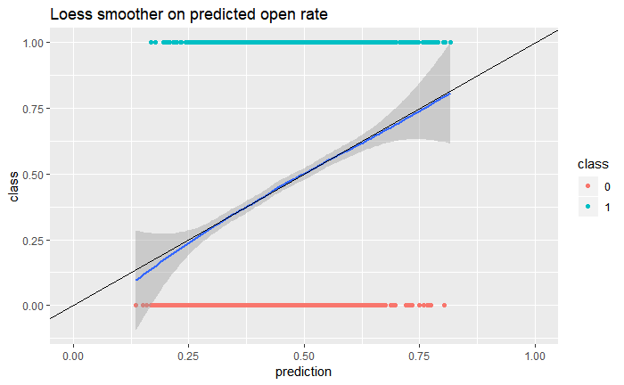

```r
data.frame(
    class = recipients$DID_OPEN + 0
  , prediction = predict(glmod, type = 'response')
) %>%
# Plot results
ggplot(aes(x = prediction, y = class)) +
  geom_point(aes(color = as.factor(class))) +
  geom_smooth(method = 'loess') +
  geom_abline(slope = 1, intercept = 0) +
  labs(title = 'Loess smoother on predicted open rate', color = 'class') +
  xlim(c(0,1))
```

That’s an outstanding result.

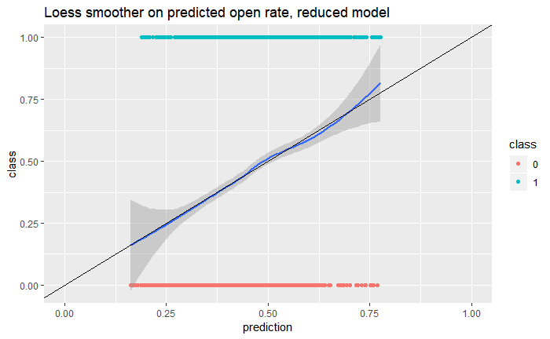

```r
data.frame(
    class = recipients$DID_OPEN + 0
  , prediction = predict(glmod_reduced, type = 'response')
) %>%
# Plot results
ggplot(aes(x = prediction, y = class)) +
  geom_point(aes(color = as.factor(class))) +
  geom_smooth(method = 'loess') +
  geom_abline(slope = 1, intercept = 0) +
  labs(title = 'Loess smoother on predicted open rate, reduced model', color = 'class') +
  xlim(c(0,1))
```

Still an excellent result with the reduced model.

# Class year effects

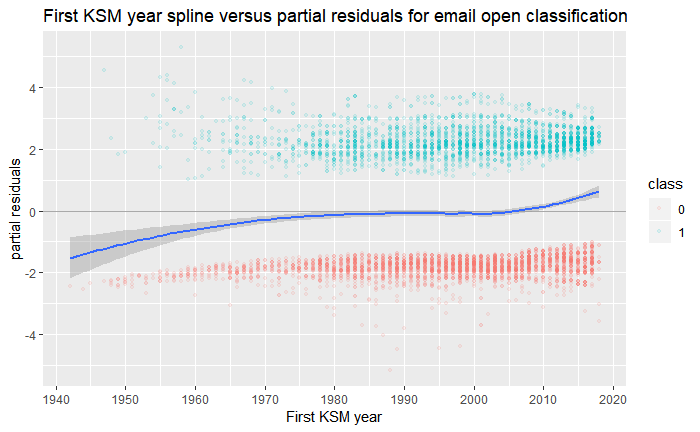

```r
data.frame(
  FIRST_KSM_YEAR = recipients$FIRST_KSM_YEAR
  , y.partial.resid = residuals(glmod, type = 'partial')[, 'ns(FIRST_KSM_YEAR, df = 5)']
  , class = as.factor(recipients$DID_OPEN + 0)
) %>%
  ggplot(aes(x = FIRST_KSM_YEAR, y = y.partial.resid)) +
  geom_point(aes(color = class, fill = class), alpha = .1, size = 1) +
  geom_hline(yintercept = 0, color = 'darkgray') +
  geom_smooth(method = 'loess') +
  scale_x_continuous(breaks = seq(0, 3000, by = 10)) +
  scale_y_continuous(breaks = seq(-10, 10, by = 2)) +
  labs(title = 'First KSM year spline versus partial residuals for email open classification'
       , x = 'First KSM year'
       , y = 'partial residuals')
```

This is exactly as expected – all else equal, younger alums are more likely to open the email than older ones.